# hw1

**Background**

Homework assignments for Math 514 will be prepared using R Markdown. R Markdown is a file format for making dynamic documents with R. R Markdown files support reproducible research and can contain text, equations (latex), R code, images and graphics.

If you are unfamiliar with R Markdown, please review

- Using R Markdown for Class Reports: http://www.stat.cmu.edu/~cshalizi/rmarkdown/
- R Markdown cheat sheet: https://www.rstudio.com/wp-content/uploads/2015/02/rmarkdown-cheatsheet.pdf

LaTeX is the most common system for typesetting mathematics. The reference [Using R Markdown for Class Reports](http://www.stat.cmu.edu/~cshalizi/rmarkdown/) has a good section on including math in R Markdown. LaTex can be daunting at first, so using a GUI can be a big help. We have found the online GUI [CodeCogs](https://www.codecogs.com/latex/eqneditor.php) to be very helpful. With a little experimentation you should be able to use the GUI to generate LaTex that you then copy/paste back into your R Markdown document.

**Homework 1 Problem Statement**

Homework 1 is unusual because we have already done it for you - except for the 6 questions at the very end. You should also make sure you understand the R code. Please type in answers for the last section and knit the document for submission along with the .Rmd in the project folder zip as instrument in homework submission guidelines announcement on canvas.

This assignment covers Bayes’ Error using a simple 1-dimensional classification problem. The problem is to simulate the tossing of two coins with different probabilities to be heads. An experiment will consist of tossing a randomly chosen coin N times. The problem is to determine (classify) which coin was chosen.

The classifier will be built using Bayes’ Rule. Classifier testing data will be generated using simulated coin tosses. The testing data will consist of M experiments (each with N tosses).

**Step 1**

First, write a function called *coin.toss* to simulate a set of coin toss experiments that allows you to input the probability of heads p.

Your function should take as input

- The probability of success (heads) p.
- The number of tosses in an experiment N.
- The number of experiments to run M.

The function should return the simulated coin toss data as an array with dimensions M x N. That is, each experiment is a row in the returned matrix. Use a value of 1 for head and 0 tail. Use runif function in R to create the data in a vectorized approach.

```r
coin.toss=function(p,num.tosses,num.trials){
  #first generate random numbers between 0 and 1
  #tosses can be generated in a vectorized call producing num_toss*num.trials draws
  draws=runif(num.tosses*num.trials)
  results=matrix(1*(draws < p),nrow=num.trials)
  return(results)
}
```

**Step 2**

Next, write a second function called *create.coin.toss.data* that uses *coin.toss* to generate the training data. It should take as input:

- N = the number of tosses in an experiment
- M1 = the number of experiments using coin 1
- p1 = the probability of success for coin 1
- M2 = the number of experiments using coin 2
- p2 = the porbability of success for coin 2

The function should return a matrix and a vector. The matrix should be M1+M2 rows by N columns - one row for each experiment. The vector should be M1+M2 long and contain the *tag* for each row in the matrix. Randomize the data on return.

```r
create.coin.toss.data=function(n,m1,p1,m2,p2){
  c1=coin.toss(p1,n,m1)
  c2=coin.toss(p2,n,m2)
  data=rbind(c1,c2)
  y = c(rep(0,m1),rep(1,m2))

  # what do the following lines of code do?
  i = sample(1:nrow(data))
  return(list(x=data[i,],y=y[i]))
}
```

**Step 3: Expected Value (try some LaTeX)**

Each experiment consists of N 0-1 outcomes each with probability.

Derive the following:

- The expected value and variance of a Bernoulli random variable with $P(X=1)=\theta$.
- Then compute the expected value and variance of $Y=(1/N)\Sigma_i X_i$ for $i=1 \ldots N$.

$$P(X=x|\theta)=\theta^{x}(1-\theta)^{(1-x)}$$
where lower case x is $\in$ {0,1} and $\theta$ stands in for p1 or p2, depending on the coin. Compute the expected value of this random variable (show calculation in LaTex).
$$E[X]=\sum_{i}x_i\,P(X=x_i)=0\cdot P(X=0)+1\cdot P(X=1)=0\cdot(1-\theta)+1\cdot\theta=\theta$$

Now compute the variance of X
$$\sigma^2=Var(X)=E[(X-E[X])^2]=(0-\theta)^2(1-\theta)+(1-\theta)^2\theta=(1-\theta)(\theta^2+\theta(1-\theta))=\theta(1-\theta)$$
Use these results to compute $E[Y]$ and $Var[Y]$
$$E[Y]=E[\frac{1}{N}\Sigma_{i=1}^{N}X_i]=\frac{1}{N}\Sigma_{i=1}^N(E[X_i])=\theta$$
$$Var[Y]=Var[\frac{X_1+X_2+\cdots X_n}{N}]=\frac{1}{N^2}(Var(X_1)+\cdots +Var(X_N))=\frac{N}{N^2}Var(X)=\frac{\theta(1-\theta)}{N}$$

http://stat.math.uregina.ca/~kozdron/Teaching/UBC/302Fall10/Handouts/normal_approx_to_bin.pdf

**Step 4: Try some graphics**

Call your functions to generate 100 experiments with the following parameters:

- n = 64
- m1= 40
- p1= .4
- m2= 60
- p2= .5

Plot histograms of the number of heads for both coins (same plot). Use the multiple assignment operator “%<-%” operator from the *zeallot* package to get data from your function.

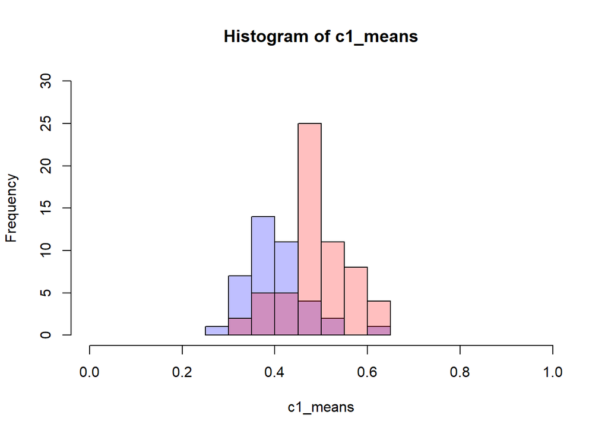

```r
n=64
m1=40; p1=.4;
m2=60; p2=.5;
c(x,y)%<-%create.coin.toss.data(n,m1,p1,m2,p2)
c2_means=rowMeans(x[y==1,])
c1_means=rowMeans(x[y==0,])
h1=hist(c1_means, col=rgb(0,0,1,1/4), xlim=c(0,1),ylim=c(0,30))
h2=hist(c2_means, col=rgb(1,0,0,1/4), xlim=c(0,1),ylim=c(0,30), add=T)
```

**Step 5: Derive Bayes’ Equation for classification**

**Bayes’ theorem**

$$P(A \mid B) = \frac{P(B \mid A) \, P(A)}{P(B)}$$

**Derive the Bayes’ discriminant function for classification:**
$$\begin{aligned}P(C_1|x) &< P(C_2|x) \\
P(C_1 \mid x) &= \frac{P(x \mid C_1) \, P(C_1)}{P(x)} \\
\frac{P(x \mid C_1) \, P(C_1)}{P(x)} &< \frac{P(x \mid C_2) \, P(C_2)}{P(x)} \\
P(x \mid C_1) \, P(C_1) &< P(x \mid C_2) \, P(C_2)\end{aligned}$$

$$d(x)=P(C_2\mid x)-P(C_1\mid x)=P(x\mid C_2)P(C_2)-P(x\mid C_1)P(C_1) \Rightarrow \left\{\begin{matrix}\ge 0 \quad C_2
\\
< \qquad C_1
\end{matrix}\right. \quad(1)$$
**Step 6: Use normal approximation of binomial distribution**

Write a discriminant funtion (equation 1 above) using normal approximations (see dnorm function in R) for the class-conditional probabilities. The function should take as inputs

- x value
- N = the number of tosses in an experiment
- M1 = the number of experiments using coin 1
- p1 = the probability of success for coin 1
- M2 = the number of experiments using coin 2
- p2 = the porbability of success for coin 2

This function will be $\ge 0$ if class 2 is more likely. The optimial cut point is when the discriminant is equal to 0. Write a function (using a root finder) to compute the optimal Bayes’ cut (again with normal approximations).

```r
# value > 0 --> class 2
#P(X|C) is approximated by normal denisty from dnorm and P(C) is approximated using m1/(m1+m2) and since both side of the inequality have the same denominator we can leave out the division by (m1+m2)
bayes.discriminant=function(x,n,m1,p1,m2,p2){
  # compute binomial standard deviation - use for normal approximation
  s1=sqrt(p1*(1-p1)/n)
  s2=sqrt(p2*(1-p2)/n)
  # don't need to divide by (m1+m2), just care about positive/negative
  dnorm(x,p2,s2)*m2 - dnorm(x,p1,s1)*m1
}

# use a root finder to determine where descriminant is zero
# type ?uniroot to see what function documentation says about uniroot and note typing the function shows the code of function in R
bayes.cut.norm=function(n,m1,p1,m2,p2){
  ff=function(x){bayes.discriminant(x,n,m1,p1,m2,p2)}
  uniroot(ff,c(p1,p2))$root
}
```

**Step 7: Compute Bayes’ Error**

Use the bayes’ optimal cut to compute the theoretical bayes’ error for the bayes’ decision rule. The Bayes’ error is the sum of the areas of overlap weighted by their class probabilities. Use the R function *pnorm* to compute needed tails of normal approximations to the class conditional probabilities.

```r
bayes.error=function(cut,n,m1,p1,m2,p2){
  s1=sqrt(p1*(1-p1)/n)
  s2=sqrt(p2*(1-p2)/n)
  w1=m1/(m1+m2)
  w2=1-w1
  if(p1 < p2){
    error=w2*pnorm(cut,p2,s2)+w1*(1-pnorm(cut,p1,s1))
  }else{
    error=w1*pnorm(cut,p1,s1)+w2*(1-pnorm(cut,p2,s2))
  }
  error
}
```

**Step 8 Classify new experiments using Bayes’ cut**

Compute the bayes’ cut and the Bayes’ error. Use the cut to evaluate classification performance on new data. Run 30 trials and plot performance against the Bayes’ error.

```r
cut=bayes.cut.norm(n,m1,p1,m2,p2)
cut
```

```
## [1] 0.4347043
```

```r
b.err=bayes.error(cut,n,m1,p1,m2,p2)
b.err
```

```
## [1] 0.2030252
```

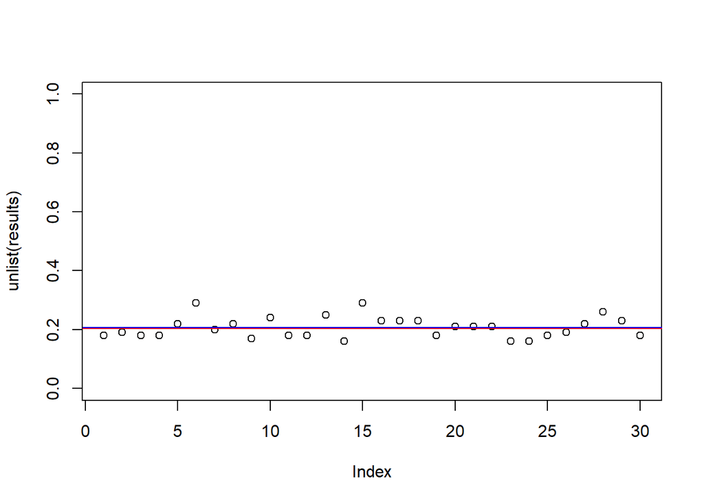

```r
bayes.1d.accuracy=function(X,y,cut){
  sum(as.integer(rowMeans(X) > cut)==y)/length(y)
}

results=list(mode='vector')

for (i in 1:30){
  c(x,y) %<-% create.coin.toss.data(n,m1,p1,m2,p2)
  results[[i]]=1-bayes.1d.accuracy(x,y,cut)
}
plot(unlist(results),ylim=c(0,1));
abline(h=b.err,col='red');
abline(h=mean(unlist(results)),col='blue')
```

**Step 9**

**Provide text answers to the following questions**

- Q1 Step 1: In the function coin.toss, why is (draws < p) multiplied by 1?
- Q2 Step 2: In the function create.coin.toss.data, explain what the last two lines accomplish, other than returning the data to the caller
- Q3 Step 4: In the histograms, what makes the colors translucent?
- Q4 Step 6: In the function bayes.cut.norm, what does the argument c(p1,p2) to uniroot do and why is it a reasonable choice?
- Q5 Step 7: In the function bayes.error, why is there a check for p1 < p2?
- Q6 Step 8: The function bayes.1d.accuracy is very compact. Explain the steps to computing accuracy.